# Oxford Happiness Questionnaire

coop711

2023-10-16

옥스포드 행복 설문지 실험결과를 분석한다. 이 실험에는 두 가지 목적이 있다. 첫째는 있는 그대로 옥스포드 행복 설문지로 측정하는 여러분의 행복 수준은 어느 정도인지, 둘째는 영문판으로 응답할 때와 국문판으로 응답할 때 어떤 차이가 있는지, 특히 응답에 소요되는 시간을 측정해 보았다.

## Red, Black을 잘못 표시한 사람들

| 제출시간 | 학번 | 랜덤화출석부 | 구글예습퀴즈 |
| --- | --- | --- | --- |
| 2023-10-19 22:31:17 | 20233834 | Red | Black |
| 2023-10-20 23:11:08 | 20224152 | Black | Red |
| 2023-10-27 22:28:21 | 20183401 | Red | Black |

|  | Red(옥스포드행복설문지) | Black(옥스포드행복설문지) |
| --- | --- | --- |
| **Red(랜덤화출석부)** | 315 | 2 |
| **Black(랜덤화출석부)** | 1 | 318 |

## 행복 점수 비교

### `summary()`

- **국문**:

  | Min. | 1st Qu. | Median | Mean | 3rd Qu. | Max. |
  | --- | --- | --- | --- | --- | --- |
  | 1.759 | 3.586 | 4 | 4.06 | 4.517 | 5.655 |

- **영문**:

  | Min. | 1st Qu. | Median | Mean | 3rd Qu. | Max. | NA’s |
  | --- | --- | --- | --- | --- | --- | --- |
  | 1.828 | 3.517 | 3.862 | 3.942 | 4.31 | 5.655 | 6 |

### `table()`

|  | 행복하지 않다 | 다소 행복하지 않다 | 그저 그렇다 | 꽤 행복하다 | 매우 행복하다 | NA | 계 |
| --- | --- | --- | --- | --- | --- | --- | --- |
| **국문** | 1 | 13 | 142 | 125 | 35 | 0 | 316 |
| **영문** | 1 | 4 | 178 | 112 | 19 | 6 | 320 |
| **계** | 2 | 17 | 320 | 237 | 54 | 6 | 636 |

Pearson’s Chi-squared test with simulated p-value (based on 2000 replicates): `.`

| Test statistic | df | P value |
| --- | --- | --- |
| 14.29 | NA | 0.007496 * * |

### 백분율(%)

[output not shown]

### `geom_boxplot()`

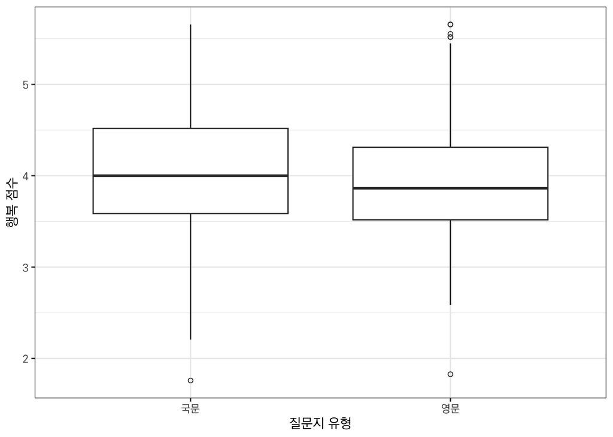

### `t.test()` on means

Welch Two Sample t-test: `Scores` by `group`

| Test statistic | df | P value | Alternative hypothesis | mean in group 국문 | mean in group 영문 |
| --- | --- | --- | --- | --- | --- |
| 2.329 | 620.7 | 0.0101 * | greater | 4.06 | 3.942 |

## 소요시간 비교

초 단위로 측정한 소요시간에서는 오전, 오후를 잘못 쓴다거나 시작 시간이 제출 시간보다 늦게 입력한 사람들이 있고, 과도하게 (한 시간) 이상 소요된 것으로 나오는 사람들이 있어서 일일이 찾아서 수정하였고, 한 시간 이상은 사실상 설문지를 작성하다가 다른 일을 하고 다시 돌아와 마치는 과정을 의미하는 것으로 판단하여 NA 로 처리하였다. 소요 시간에 있어서도 국문과 영문에는 통계적으로 매우 유의한 수준의 차이가 관찰되었다.

평균적으로 111초, 즉 1분 51초정도 국문 질문지에 더 빨리 응답한다. 소요시간의 중위값을 비교해 보면 70 초, 약 1분 10초 만큼 국문 질문지에 더 빨리 응답하지만 통계적으로 유의한 수준은 아니다.

### `summary()`

- **국문**:

  | Min. | 1st Qu. | Median | Mean | 3rd Qu. | Max. | NA’s |
  | --- | --- | --- | --- | --- | --- | --- |
  | 25 | 139 | 182 | 246.4 | 251.8 | 2797 | 30 |

- **영문**:

  | Min. | 1st Qu. | Median | Mean | 3rd Qu. | Max. | NA’s |
  | --- | --- | --- | --- | --- | --- | --- |
  | 2 | 138 | 252 | 357.4 | 424 | 2475 | 47 |

### `geom_boxplot()`

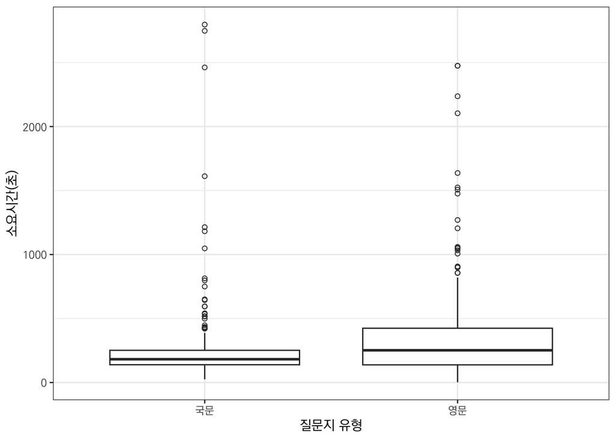

### `t.test()` on means

Welch Two Sample t-test: `as.numeric(Duration)` by `group`

| Test statistic | df | P value | Alternative hypothesis | mean in group 국문 | mean in group 영문 |
| --- | --- | --- | --- | --- | --- |
| -3.87 | 528.2 | 0.0001227 * * * | two.sided | 246.4 | 357.4 |

## 일 단위 마감 시간으로부터 제출 시간의 분포

### 분포표

일 단위

|  | [0,1] | (1,2] | (2,3] | (3,4] | (4,5] | (5,6] | (6,7] | (7,8] | (8,9] | (9,10] | (10,11] | (11,12] | (12,13] | (13,14] |
| --- | --- | --- | --- | --- | --- | --- | --- | --- | --- | --- | --- | --- | --- | --- |
| **국문** | 25 | 28 | 16 | 12 | 10 | 14 | 21 | 62 | 39 | 24 | 23 | 18 | 11 | 13 |
| **영문** | 29 | 34 | 8 | 4 | 13 | 14 | 20 | 68 | 29 | 24 | 23 | 20 | 21 | 13 |

### 막대그래프

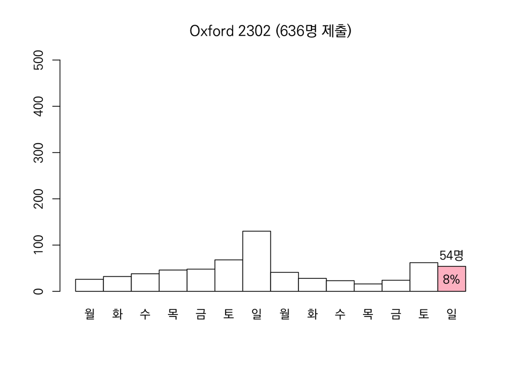

### Mosaic Plot

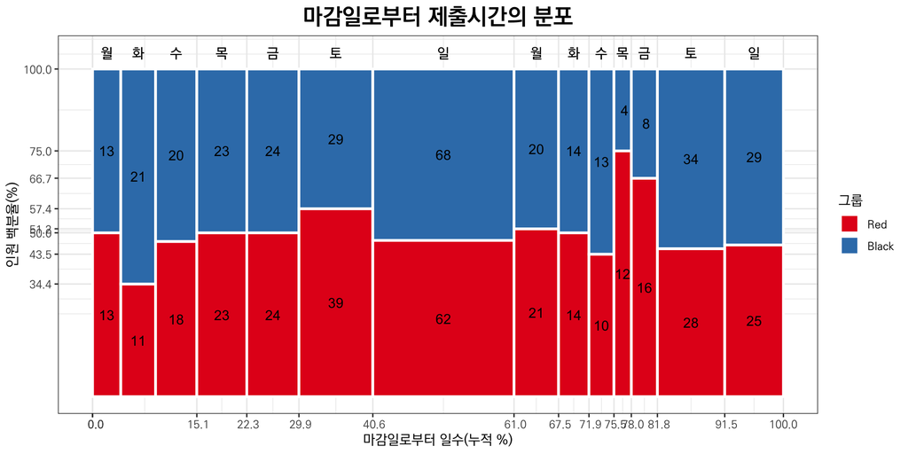